# Story

AB-4

2023-12-08

# Introduction

Our project focuses on the trend of CO2 production in every country for the last 30 years and how it might be related to different factors, such as the human development index and population. CO2 has been a conversation of worry for quite some time since it affects our planet and everyone living on it which is why it’s an interesting and important topic.

Everyone has heard about climate change and global warming. Climate change are long term changes in temperatures and weather patterns and one of the results of climate change is global warming. Global warming is what it says, the warming of the globe, Earth. One of the main factors that contribute to global warming is the amount of CO2 in the atmosphere. How this works is that CO2 is a greenhouse gas, along with H2O, and greenhouse gasses trap and absorb heat which results in the greenhouse effect. The greenhouse effect is when the CO2 and water vapor in the atmosphere absorb the infrared energy from Earth and instead of emitting it back to space, it gets emitted back to Earth and hence, the warming of Earth. It’s essentially a big blanket covering the Earth. We know that CO2 is one of the main perpetrators of climate change and global warming so if we produce more CO2 then the greenhouse effect will become more severe.

In the past few centuries, the emission of CO2 has increased by 50% and it’s basically all because of human activities. Mostly fossil fuel burning, deforestation, and cement production which is why global warming is such a hot topic nowadays. The more CO2 produced, the more intense global warming is and this impacts the human health, environment, precipitation patterns, and sea level everywhere on Earth since CO2 is well mixed in the atmosphere and it remains in the atmosphere for thousands of years.

As mentioned before, our project focuses on CO2 and how it is affected by human development and population. More specifically we delve into the correlation between CO2 production and the population of a country since it is known that humans are the main contributors to the CO2 in the atmosphere, so how does the population affect it? Next, we compare the CO2 production in a country from each continent from 1990 and 2019. This is to see how CO2 has changed in the past 30 years and how it is different for each country. Then we compare the Human Development Index (HDI) and the population of a country to observe how population can affect human development or if it affects it all. Finally, we compare HDI with the CO2 production in 2019 since cement production and fossil fuel burning are strong contributors of the CO2 in the atmosphere. So, how does the development of humans correlate with the CO2 production, if there is any?

CO2 production and human development are interesting topics and are something everyone needs to know about because this process of climate change and global warming affects everyone on Earth and the planet itself. We are the main perpetrators of global warming and we are harming ourselves in the long run if we don’t consider the consequences of our actions. Reading our report will help researchers, or anyone, understand some of the causes and effects that human development and population have on CO2 production and they can use this to figure out ways to decrease the numbers in the long run and potentially save the Earth and human health.

# Data

We used our datasets, “World Population by Countries”, “Global Socio-Economic and Environmental Indicators”, and “CO2 Emissions” to illustrate the relationship between CO2 Production levels and Human Development Index (HDI), as well as how they can correlate with and introduce different dynamics when compared to the population of a country. Additionally, we aimed to understand how these variables could also differ when looking at the difference between the years 1990 and 2019. Our datasets originated from the platform “Kaggle”. The world population dataset is owned by the user, “ASHWIN.S” and was sourced from the website data.worldbank.org. The data was also cleaned using Pandas. The global socio-economic and environmental indicators dataset is owned by the user, “toriqul” and sourced from the Human Development Reports website, hdr.undp.org, and was collected with web scripting. The CO2 Emissions dataset is owned by the user, Urik Thyge Pedersen, and was sourced from the website https://data.nasdaq.com/databases/WB/data as well as the United Nations Framework Convention on Climate Change (UNFCCC) and the International Energy Agency (IEA). This data was available for free on Kaggle to anyone who wished to use it. The only observable restriction was making an account on Kaggle in order to gain access to download the data files. Although there was no explicit statement on what purpose the data should be used for in the world population dataset, the global socio-economic and environmental indicators dataset detailed that it would be valuable for researchers, analysts, and policymakers interested in various aspects of global development and sustainability. Additionally, there was included input from users who downloaded the dataset, with most saying they used it for learning purposes, and a few stating that it was used for research. The CO2 emissions dataset stated that it can be used by researchers, policymakers, and the general public to gain insight into the relative contributions of different countries to global CO2 emissions. It also declared that it could be used to monitor changes in emissions over time and to assess the effectiveness of climate policies. The world population dataset contains every nation’s population from 1960 to 2019. The variables consist of the country name, its three-letter country code, and the year (1960 to 2019). The global socio-economic and environmental indicators dataset contains four separate files that provide data on different sets of information: CO2 Production, Gross National Income (GNI) per Capita, Human Development Index (HDI), and Life Expectancy by Birth. We only utilized the HDI data file for our project. The file covers the Human Development Index from year 1990 to 2019 along with associated metrics, offering insights into socio-economic development trends across countries and regions. The variables consist of the country name, the three-letter country code, the HDI code, the region, the HDI rank for the year 2019, and the HDI for each year from 1990 to 2019. Its intended uses are to analyze long-term trends in HDI scores and rankings, investigate the relationship between HDI and other socio-economic factors, and assess regional disparities in human development. The CO2 emissions dataset covers the amount of CO2 emitted from each country from 1960 to 2019. The variables consist of the three-letter country code, the country name, the year, and “value”, as in the amount of CO2 emitted by each country in kilotons (kt). There were no data quality issues that we encountered when dealing with the datasets; apart from identifying the specific names of countries we wanted to plot, everything was discovered and sought out clearly.

In our final dataset, each row represents the CO2 production levels, population, HDI, and the CO2 Index for a country in a certain year. We have 4,980 observations in our dataset. The relevant variables are “Country”, which is the country’s name, “Country Code”, containing the three-letter country code, “Year”, with years spanning from 1990 to 2019, “CO2 Production”, depicting the total carbon emissions in a country in a certain year, “Population”, which states the total country population in a given year, “HDI”, which depicts the HDI for a country in a given year, “CO2Index”, which is a categorical variable that gives a certain index of a country’s CO2 level depending on where it falls in our caliber (3,569,073 kt and below = “Low”, 3,569,074 kt to 7,138,146 = “Middle”, and 7,138,147 kt and above = “High”), “AvgCO2”, which is a numerical variable that gives the calculated average CO2 production for a certain country across all years, and finally, “AvgPop”, which is a numerical variable that gives the calculated average population for a certain country across all years. Additionally, we created a summarized dataset called “mergesum” containing the average HDI levels for each country and the average population for each country. There are a few missing values in the key variables for our dataset. The “Population” variable has 11 missing values, and the “HDI” variable has 519 missing values. Although we had a few missing values, which may have deterred the quality of our dataset, it didn’t hinder our ability to plot the relationships we wanted to. Additionally, our idea of creating the “AvgPop” variable in order to plot the average values of this data allowed the missing values to decrease significantly, which made it easier for us to plot the relationships for the countries we chose.

# Methods

For this project from the three datasets, we decided to hone in on three subjects of information about countries around the world. These are Co2 Production, Human Development Index, and Population which each came from separate datasets. From each of these datasets we opted to take only one variable (the yearly measures of co2, hdi, and population) for the merged final product in order to be as clean as possible for our final data manipulation to create our plots. We also appreciated the very raw variables we chose because they were easier to manipulate into the secondary (categorical/numerical) variables required for the project.

For all of our datasets we need to pivot them from the wide form they currently are in into long form to cleanly display more variables. We’ll make what was once many columns of individual years into one column with all of the years. This variable year in addition to the country code variable that we also have access to in all datasets will be the common variables that allows us to merge it all into one. For all of the datasets we need to make unified the naming conventions for the country code variables (“Country Code”). Individually we also want to make simple the naming convention for all column names that represent a single year’s worth of data. Co2 for example has a prefix “co2_prod_” before the year. This is done for Co2 and HDI using sub() and assignment to names() to replace their respective prefixes with empty (“”) strings before any pivoting of the datasets. In the case of the population dataset we also use rename() to rename the variable “Country Name” to be “Country” for simplicity.  
Next we need to pivot_longer each of these datasets and remove any extraneous variables not useful to us. For each of these datasets we only focused on the yearly information recorded for each country in its respective subject. For hdi this is a decimal value index every year so we create a second version of this dataset in longer form, then after that we create a third that strips away extraneous variables. These extraneous variables are hdi code, region, and rank 2021. This makes the data cleaner as information like region will be the same for each country no matter the year and just takes up space in this longer format without additional information provided. This limits us however as we are now unable to make plots based on region for example to group countries, something we decided is not important to the plots we want to make. The same is done for the human development index (hdi code, region, and rank in 2021) and we strip the Country Name variable from both the HDI and Co2 datasets so that we just use the names from the population dataset. There is some difference in country names between the sets so to avoid losing data we just use the names from one.

Finally, we use inner_join() to first combine the co2 and population dataset, then combine that merged dataset with the hdi data into one final one. In doing so we only keep data that has both the same country code and a year of data on file. This allows us to keep the most data possible from our different sets as the country codes are the same between each of the datasets. Though they each have different ranges of time that they cover. Thus where co2 has data up until 2019 as opposed to the other two that go up until 2021. We end up losing the data for those non-similar years but this doesn’t affect us too much because we wouldn’t want to have information we can’t compare with anything anyways. With this final dataset we make some final decisions. We create a co2 index variable (categorical) and an average population variable (numerical) to additionally measure our data. We do this ignoring rows with N/A values in the respective original variable. We also make sure to mutate() our year variable to be numeric as opposed to a string.

As for our sample chosen, when making the bar chart we decided to focus only on some specific countries. This is for simplicity of display and audience understanding as we have a lot of countries that could be represented. This bar chart gives a snapshot with one country from each continent to get a general idea of how the leading countries in each region compare to each other as Australia, Brazil, China, Russia, the United States, and Nigeria all have the highest populations in their respective countries. All the other plots we created use the entirety of our data excluding any n/a values which there were few of.

We did not end up using many complex statistical methods, though our scatterplots did have an aspect of linear regression. We didn’t do any solving for specific correlation coefficients, but we did add trend lines to our graphs. The first of which for our HDI vs Population scatterplot we used a linear model to show a downward trend. With this, we see visually that there is a wide spread away from the line and thus the relationship is weak with many possible outliers. For our second graph we allowed rstudio to generate its own trend line that is non-linear and here we see that for the left section of the data where most of our points are there is a clear positive trend until some large outliers change the trajectory for the line.

# Results

Our first question tackled the correlation between CO2 production and population. We used a map visualization to compare how these two variables correlated for different countries in 2019. We can see in the CO2 Production map, some of the countries with the highest production include China, the United States, and India. Similarly, for the population map, some of the countries with the highest population are China, the United States, and India. While it does seem that there is a positive correlation between population and CO2 production, it does not seem to be a direct correlation. This can be seen in how Russia had a lower population than Brazil but had a higher CO2 production. Additionally, India had a greater population than the US but had a lower CO2 production.

[output not shown]

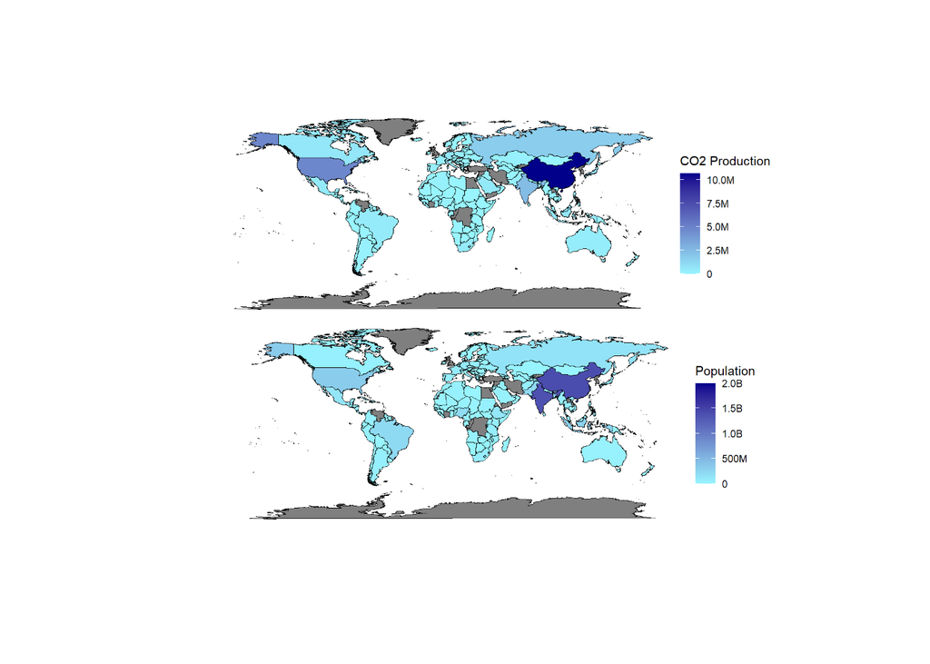

Our second question aimed to address how CO2 production has changed between the years 1990 and 2019. We chose one country from every continent (excluding Antarctica) to compare the change: Australia, Brazil, China, Nigeria, Russian Federation, and the United States. For most of the countries chosen, CO2 had increased. More specifically, CO2 production decreased in the Russian Federation and the United States, while increased in Brazil, China, Nigeria, and Australia.

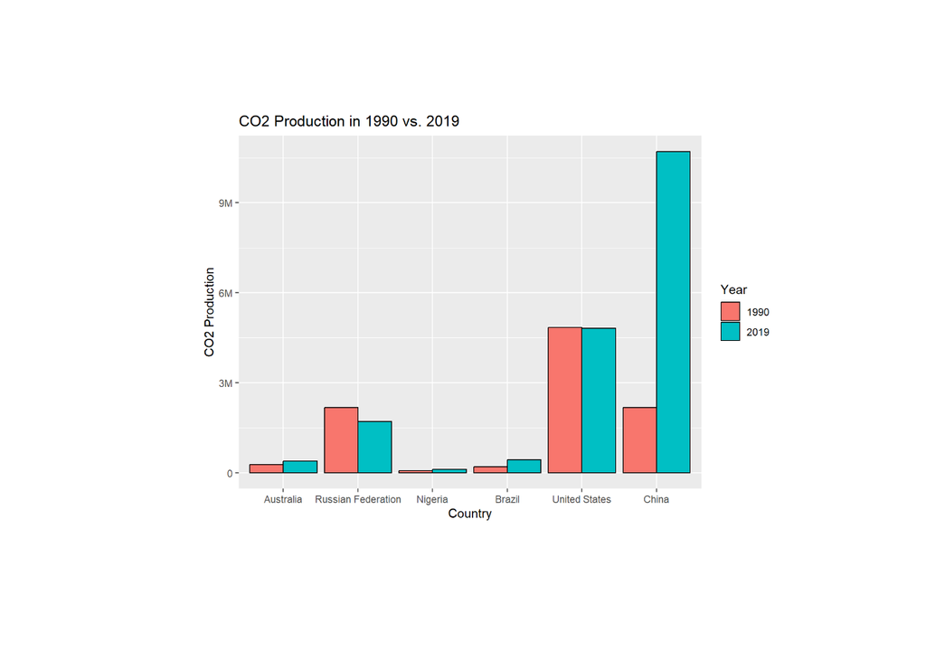

In our third question, we wanted to visualize the correlation between the population and human development index (HDI) of countries. We used an average of the population and HDI over the years for each country for more summarized data for each country and ease of visualization. The slope of the regression line is not very steep, which could indicate that there isn’t too strong of a correlation. While the data is quite scattered at lower population levels, the general trend is that with increasing population, there is a decrease in HDI.

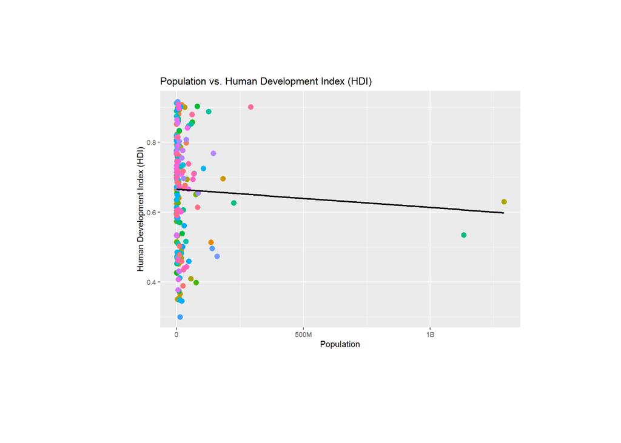

Our fourth question addresses the correlation of HDI vs CO2 production, using data from different countries in 2019. The initial trend we see is a rapid increase in the relationship between HDI and CO2 production before the trend ultimately decreases at higher levels of CO2 production.

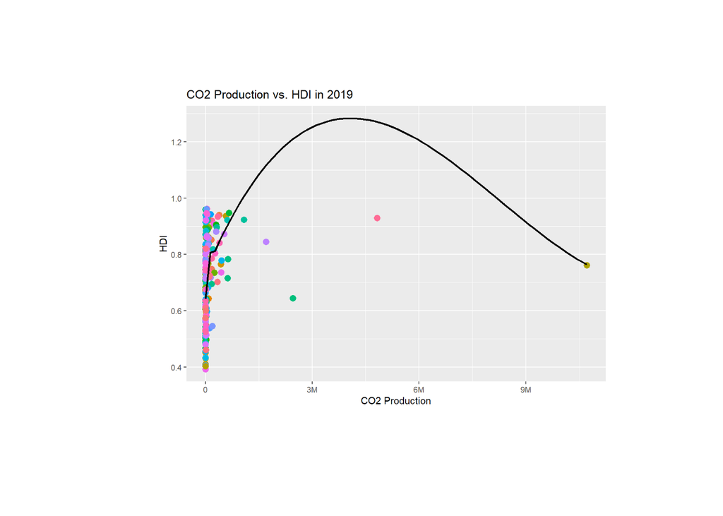

# Findings

Some future work to further build on this topic is to look in how this data compares over the years and if the years we specifically used were an outlier and to look in how this data compares for a wider variety of countries to pinpoint a worldwide trend and see if it follows with the trend we observe with our current data.

# Summary

The overall idea that can be gathered from our plots and the final dataset is that the population of a country may not be the best indicator of its CO2 production levels, rather, its HDI (Human Development Index) may be a better indicator. As discussed in the introduction, humans are the main contributors to the extreme CO2 levels in the atmosphere across the world, no matter the country. However, although some may like to believe that the number of people in the world is the main contributor to these excessive levels of CO2 emissions, it is actually the various levels of development of humans on Earth that can cause different levels of CO2 emissions.

There were a few limitations in our project. The first is that we used the average population and average HDI levels to plot the graph for the third research question, which could have affected the true relationship between the two variables since the averages could have left out important information about growth and dips between HDI levels and population. Additionally, our data was only calculated up until the year 2019, which makes it a little dated, and it may not accurately depict the state of climate change and global warming in our world today. Because the most recent year is 2019, it also excludes data taken post-COVID-19 – the pandemic could have massively impacted the rate of CO2 production globally, and this data may not reflect that.

With our project, we wanted to figure out the trends and correlations between CO2, HDI, and population. With what was shown, even though it might not be perfect, it can help researchers find solutions to understand the different factors that contribute to the rise in CO2 production and how they change over time. By knowing that HDI has a correlation with CO2 production, this can help find solutions to decrease CO2 production overall in all countries by finding more eco-friendly ways to develop.